# RxODE Simulation

Matthew L. Fidler, Melissa Hallow, and Wenping Wang

2019-04-18

[figure not shown]

# Simulation of Variability with RxODE

Variability in model parameters can be simulated by creating a matrix of parameter values for use in the simulation. In the example below, 40% variability in clearance is simulated.

```r
set.seed(42);
library(RxODE)
mod <- RxODE({
    eff(0) = 1
    C2 = centr/V2;
    C3 = peri/V3;
    CL =  TCl*exp(eta.Cl) ## This is coded as a variable in the model
    d/dt(depot) =-KA*depot;
    d/dt(centr) = KA*depot - CL*C2 - Q*C2 + Q*C3;
    d/dt(peri)  =                    Q*C2 - Q*C3;
    d/dt(eff)  = Kin - Kout*(1-C2/(EC50+C2))*eff;
})

theta <- c(KA=2.94E-01, TCl=1.86E+01, V2=4.02E+01,  # central
               Q=1.05E+01, V3=2.97E+02,                # peripheral
               Kin=1, Kout=1, EC50=200)                # effects
```

Each subproblem can be simulated by using the rxSolve function to run the simulation for each set of parameters of in the parameter matrix.

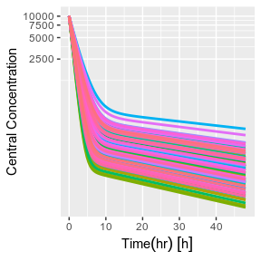

```r
## the column names of the omega matrix need to match the parameters specified by RxODE
omega <- matrix(0.4^2,dimnames=list(NULL,c("eta.Cl")))

ev <- eventTable(amount.units="mg", time.units="hours") %>%
    add.dosing(dose=10000, nbr.doses=1, dosing.to=2) %>%
    add.sampling(seq(0,48,length.out=100));

sim  <- rxSolve(mod,theta,ev,omega=omega,nSub=100)

library(ggplot2)

ggplot(sim,aes(time,centr,color=factor(sim.id))) + geom_line(size=1) + coord_trans(y = "log10") + ylab("Central Concentration") +
    xlab("Time (hr)") + guides(color=FALSE)
```

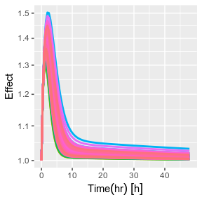

```r
ggplot(sim,aes(time,eff,color=factor(sim.id))) + geom_line(size=1) + coord_trans(y = "log10") + ylab("Effect") +
    xlab("Time (hr)") + guides(color=FALSE)
```

It is now straightforward to perform calculations and generate plots with the simulated data. Below, the 5th, 50th, and 95th percentiles of the simulated data are plotted.

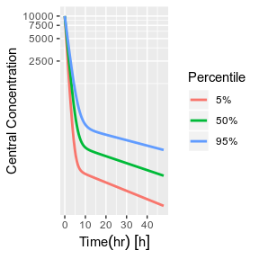

```r
library(dplyr)

p <- c(0.05, 0.5, 0.95);
s <-sim %>% group_by(time) %>%
    do(data.frame(p=p, eff=quantile(.$eff, probs=p),
                  eff.n = length(.$eff), eff.avg = mean(.$eff),
                  centr=quantile(.$centr, probs=p),
                  centr.n=length(.$centr),centr.avg = mean(.$centr))) %>%
    mutate(Percentile=factor(sprintf("%d%%",p*100),levels=c("5%","50%","95%")))

ggplot(s,aes(time,centr,color=Percentile)) + geom_line(size=1) + coord_trans(y = "log10") + ylab("Central Concentration") +
    xlab("Time (hr)")
```

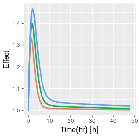

```r
ggplot(s,aes(time,eff,color=Percentile)) + geom_line(size=1) + ylab("Effect") +
    xlab("Time (hr)") + guides(color=FALSE)
```

Note that you can see the parameters that were simulated for the example

```r
head(sim$param)
```

```
##   sim.id   V2  V3  TCl      eta.Cl    KA    Q Kin Kout EC50
## 1      1 40.2 297 18.6 -0.23883576 0.294 10.5   1    1  200
## 2      2 40.2 297 18.6  0.37204656 0.294 10.5   1    1  200
## 3      3 40.2 297 18.6 -0.60662015 0.294 10.5   1    1  200
## 4      4 40.2 297 18.6 -0.08291157 0.294 10.5   1    1  200
## 5      5 40.2 297 18.6 -0.18610920 0.294 10.5   1    1  200
## 6      6 40.2 297 18.6 -0.24490319 0.294 10.5   1    1  200
```

You can also supply a data-frame of parameters to simulate instead of using an omega simulation. In this contrived example we will use the previously simulated data.

```r
theta <- sim$param;
sim  <- rxSolve(mod,theta,ev)
rxHtml(sim)
```

| **Solved RxODE object** |
| --- |
| **Parameters** (**$params**): |
| sim.id V2 V3 TCl eta.Cl KA Q Kin Kout EC50 1 40.2 297 18.6 -0.2388358 0.294 10.5 1 1 200 2 40.2 297 18.6 0.3720466 0.294 10.5 1 1 200 3 40.2 297 18.6 -0.6066202 0.294 10.5 1 1 200 4 40.2 297 18.6 -0.0… |
| **Initial Conditions** ( **$inits**): |
| depot centr peri eff 0 0 0 1 **First part of data (object):** sim.id time C2 C3 CL depot centr peri eff 1 0.0000000 [h] 248.75622 0.000000 14.64832 0 10000.000 0.000 1.000000 1 0.4848485 [h] 183.89373… |

Even though multiple subjects were simulated, this is still a reactive data frame, meaning you can change things about the model on the fly.

For example, if the effect at time 0 should have been 100, you can fix this by:

```r
sim$eff0 <- 100
rxHtml(sim)
```

| **Solved RxODE object** |
| --- |
| **Parameters** (**$params**): |
| sim.id V2 V3 TCl eta.Cl KA Q Kin Kout EC50 1 40.2 297 18.6 -0.2388358 0.294 10.5 1 1 200 2 40.2 297 18.6 0.3720466 0.294 10.5 1 1 200 3 40.2 297 18.6 -0.6066202 0.294 10.5 1 1 200 4 40.2 297 18.6 -0.0… |
| **Initial Conditions** ( **$inits**): |
| depot centr peri eff 0 0 0 100 **First part of data (object):** sim.id time C2 C3 CL depot centr peri eff 1 0.0000000 [h] 248.75622 0.000000 14.64832 0 10000.000 0.000 100.00000 1 0.4848485 [h] 183.89… |

#### Simulation of unexplained variability

In addition to conveniently simulating between subject variability, you can also easily simulate unexplained variability.

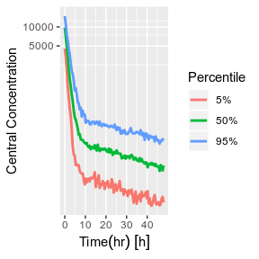

```r
mod <- RxODE({
    eff(0) = 1
    C2 = centr/V2;
    C3 = peri/V3;
    CL =  TCl*exp(eta.Cl) ## This is coded as a variable in the model
    d/dt(depot) =-KA*depot;
    d/dt(centr) = KA*depot - CL*C2 - Q*C2 + Q*C3;
    d/dt(peri)  =                    Q*C2 - Q*C3;
    d/dt(eff)  = Kin - Kout*(1-C2/(EC50+C2))*eff;
    e = eff+eff.err
    cp = centr*(1+cp.err)
})

theta <- c(KA=2.94E-01, TCl=1.86E+01, V2=4.02E+01,  # central
           Q=1.05E+01, V3=2.97E+02,                # peripheral
           Kin=1, Kout=1, EC50=200)                # effects

sigma <- diag(2)*0.1
dimnames(sigma) <- list(NULL, c("eff.err","cp.err"))


sim  <- rxSolve(mod, theta, ev, omega=omega, nSub=100, sigma=sigma)

p <- c(0.05, 0.5, 0.95);
s <-sim %>% group_by(time) %>%
    do(data.frame(p=p, eff=quantile(.$e, probs=p),
                  eff.n = length(.$e), eff.avg = mean(.$e),
                  centr=quantile(.$cp, probs=p),
                  centr.n=length(.$cp),centr.avg = mean(.$cp))) %>%
    mutate(Percentile=factor(sprintf("%d%%",p*100),levels=c("5%","50%","95%")))

ggplot(s,aes(time,centr,color=Percentile)) + geom_line(size=1) + coord_trans(y = "log10") + ylab("Central Concentration") +
    xlab("Time (hr)")
```

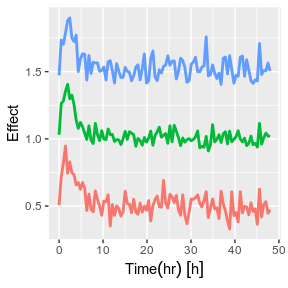

```r
ggplot(s,aes(time,eff,color=Percentile)) + geom_line(size=1) + ylab("Effect") +
    xlab("Time (hr)") + guides(color=FALSE)
```

#### Simulation of Individuals

Sometimes you may want to match the dosing and observations of individuals in a clinical trial. To do this you will have to create a data.frame using the `RxODE` event specification as well as an `ID` column to indicate an individual. The RxODE event vignette talks more about how these datasets should be created.

Instead of using nlmixr for this simple example, I will combine two RxODE event tables.

```r
ev1 <- eventTable(amount.units="mg", time.units="hours") %>%
    add.dosing(dose=10000, nbr.doses=1, dosing.to=2) %>%
    add.sampling(seq(0,48,length.out=10));

ev2 <- eventTable(amount.units="mg", time.units="hours") %>%
    add.dosing(dose=5000, nbr.doses=1, dosing.to=2) %>%
    add.sampling(seq(0,48,length.out=8));

dat <- rbind(data.frame(ID=1, ev1$get.EventTable()),
             data.frame(ID=2, ev2$get.EventTable()))


## Note the number of subject is not needed since it is determined by the data
sim  <- rxSolve(mod, theta, dat, omega=omega, sigma=sigma)

sim %>% select(id, time, e, cp)
```

```
##    id          time         e          cp
## 1   1  0.000000 [h] 1.1062517 4456.646344
## 2   1  5.333333 [h] 1.3497727  341.324470
## 3   1 10.666667 [h] 1.0046824  193.351840
## 4   1 16.000000 [h] 0.9320987   54.932311
## 5   1 21.333333 [h] 0.9184267   62.081461
## 6   1 26.666667 [h] 0.8216998   21.285549
## 7   1 32.000000 [h] 0.5856710   89.440303
## 8   1 37.333333 [h] 0.9387878   62.370854
## 9   1 42.666667 [h] 0.9791421   78.795529
## 10  1 48.000000 [h] 0.8765182   94.805161
## 11  2  0.000000 [h] 1.1109873 4643.837151
## 12  2  6.857143 [h] 0.9887559   75.655019
## 13  2 13.714286 [h] 1.1978570   23.609678
## 14  2 20.571429 [h] 1.4758890   54.211423
## 15  2 27.428571 [h] 1.5740115   30.579824
## 16  2 34.285714 [h] 0.4820187   20.341122
## 17  2 41.142857 [h] 0.9270456   10.241666
## 18  2 48.000000 [h] 0.9148543    5.287749
```

#### Simulation of Clinical Trials

By either using a simple single event table, or data from a clinical trial as described above, a complete clinical trial simulation can be performed.

Typically in clinical trial simulations you want to account for the uncertainty in the fixed parameter estimates, and even the uncertainty in both your between subject variability as well as the unexplained variability.

`RxODE` allows you to account for these uncertainties by simulating multiple virtual “studies,” specified by the parameter `nStud`. In a single virtual study:

- A Population effect parameter is sampled from a multivariate normal distribution with mean given by the parameter estimates and the variance specified by the named matrix `thetaMat`.
- A between subject variability/covariance matrix is sampled from either a scaled inverse chi-squared distribution (for the univariate case) or a inverse Wishart that is parameterized to scale to the conjugate prior covariance term, as described by the [wikipedia article](https://en.wikipedia.org/wiki/Scaled_inverse_chi-squared_distribution). (This is not the same as the [scaled inverse Wishart distribution](http://andrewgelman.com/2012/08/22/the-scaled-inverse-wishart-prior-distribution-for-a-covariance-matrix-in-a-hierarchical-model/) ). In the case of the between subject variability, the variance/covariance matrix is given by the ‘omega’ matrix parameter and the degrees of freedom is the number of subjects in the simulation.
- Unexplained variability is also simulated from the scaled inverse chi squared distribution or inverse Wishart distribution with the variance/covariance matrix given by the ‘sigma’ matrix parameter and the degrees of freedom given by the number of observations being simulated.

The covariance/variance prior is simulated from `RxODE`s `cvPost` function.

An example of this simulation is below:

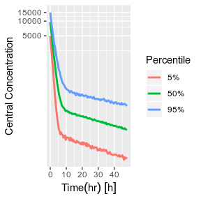

```r
## Creating covariance matrix
tmp <- matrix(rnorm(8^2), 8, 8)
tMat <- tcrossprod(tmp, tmp) / (8 ^ 2)
dimnames(tMat) <- list(NULL, names(theta))

sim  <- rxSolve(mod, theta, ev, omega=omega, nSub=100, sigma=sigma, thetaMat=tMat, nStud=10,
     dfSub=10, dfObs=100)

p <- c(0.05, 0.5, 0.95);
s <-sim %>% group_by(time) %>%
    do(data.frame(p=p, eff=quantile(.$e, probs=p),
                  eff.n = length(.$e), eff.avg = mean(.$e),
                  centr=quantile(.$cp, probs=p),
                  centr.n=length(.$cp),centr.avg = mean(.$cp))) %>%
    mutate(Percentile=factor(sprintf("%d%%",p*100),levels=c("5%","50%","95%")))

ggplot(s,aes(time,centr,color=Percentile)) + geom_line(size=1) + coord_trans(y = "log10") + ylab("Central Concentration") +
    xlab("Time (hr)")
```

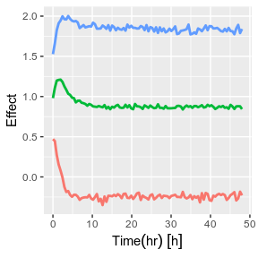

```r
ggplot(s,aes(time,eff,color=Percentile)) + geom_line(size=1) + ylab("Effect") +
    xlab("Time (hr)") + guides(color=FALSE)
```

If you wish you can see what `omega` and `sigma` was used for each virtual study by accessing them in the solved data object with `$omega.list` and `$sigma.list`:

```r
head(sim$omega.list)
```

```
## [[1]]
##           [,1]
## [1,] 0.1147344
##
## [[2]]
##           [,1]
## [1,] 0.1200283
##
## [[3]]
##           [,1]
## [1,] 0.1298885
##
## [[4]]
##           [,1]
## [1,] 0.3125934
##
## [[5]]
##           [,1]
## [1,] 0.1273521
##
## [[6]]
##           [,1]
## [1,] 0.1207694
```

```r
head(sim$sigma.list)
```

```
## [[1]]
##              [,1]         [,2]
## [1,]  0.115055008 -0.001300522
## [2,] -0.001300522  0.095544021
##
## [[2]]
##             [,1]        [,2]
## [1,] 0.115403508 0.009912083
## [2,] 0.009912083 0.103826250
##
## [[3]]
##              [,1]         [,2]
## [1,]  0.104344964 -0.002497709
## [2,] -0.002497709  0.104757997
##
## [[4]]
##             [,1]        [,2]
## [1,] 0.091556183 0.005414474
## [2,] 0.005414474 0.087806016
##
## [[5]]
##             [,1]        [,2]
## [1,] 0.092347188 0.004894803
## [2,] 0.004894803 0.091091435
##
## [[6]]
##               [,1]          [,2]
## [1,]  0.0906104390 -0.0009193655
## [2,] -0.0009193655  0.1207593030
```

You can also see the parameter realizations from the `$params` data frame.

If you do not wish to sample from the prior distributions of either the `omega` or `sigma` matrices, you can turn off this feature by specifying the `simVariability = FALSE` option when solving:

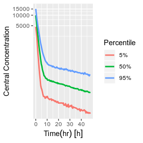

```r
sim  <- rxSolve(mod, theta, ev, omega=omega, nSub=100, sigma=sigma, thetaMat=tMat, nStud=10,
                simVariability=FALSE);

p <- c(0.05, 0.5, 0.95);
s <-sim %>% group_by(time) %>%
    do(data.frame(p=p, eff=quantile(.$e, probs=p),
                  eff.n = length(.$e), eff.avg = mean(.$e),
                  centr=quantile(.$cp, probs=p),
                  centr.n=length(.$cp),centr.avg = mean(.$cp))) %>%
    mutate(Percentile=factor(sprintf("%d%%",p*100),levels=c("5%","50%","95%")))


ggplot(s,aes(time,centr,color=Percentile)) + geom_line(size=1) + coord_trans(y = "log10") + ylab("Central Concentration") +
    xlab("Time (hr)")
```

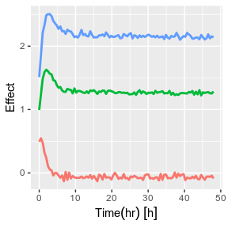

```r
ggplot(s,aes(time,eff,color=Percentile)) + geom_line(size=1) + ylab("Effect") +
    xlab("Time (hr)") + guides(color=FALSE)
```

Note since realizations of `omega` and `sigma` were not simulated, `$omega.list` and `$sigma.list` both return `NULL`.

#### RxODE multi-threaded solving and simulation

RxODE now supports multi-threaded solving on OpenMP supported compilers, including linux and windows. Mac OSX can also be supported but takes [additional setup](https://github.com/Rdatatable/data.table/wiki/Installation#openmp-enabled-compiler-for-mac). By default it uses all your available cores for solving as determined by `rxCores()`. This may be overkill depending on your system, at a certain point the speed of solving is limited by things other than computing power.

You can also speed up simulation by using the multi-cores to generate random deviates with `mvnfast`. This is controlled by the `nCoresRV` parameter. For example:

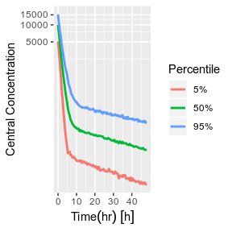

```r
sim  <- rxSolve(mod, theta, ev, omega=omega, nSub=100, sigma=sigma, thetaMat=tMat, nStud=10,
                nCoresRV=2);

p <- c(0.05, 0.5, 0.95);
s <-sim %>% group_by(time) %>%
    do(data.frame(p=p, eff=quantile(.$e, probs=p),
                  eff.n = length(.$e), eff.avg = mean(.$e),
                  centr=quantile(.$cp, probs=p),
                  centr.n=length(.$cp),centr.avg = mean(.$cp))) %>%
    mutate(Percentile=factor(sprintf("%d%%",p*100),levels=c("5%","50%","95%")))


ggplot(s,aes(time,centr,color=Percentile)) + geom_line(size=1) + coord_trans(y = "log10") + ylab("Central Concentration") +
    xlab("Time (hr)")
```

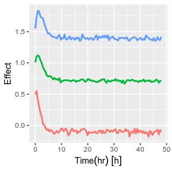

```r
ggplot(s,aes(time,eff,color=Percentile)) + geom_line(size=1) + ylab("Effect") +
    xlab("Time (hr)") + guides(color=FALSE)
```

The default for this is `1` core since the result depends on the number of cores and the random seed you use in your simulation. However, you can always speed up this process with more cores if you are sure your collaborators have the same number of cores available to them and have OpenMP thread-capable compile.